# NathanGarrity_Lab3

## Lab 3 - Vanilla CNN and Fine-Tune VGG16 - for Dogs and Cats Classification

Nathan Garrity (Student number: 8767594)

### **Introduction**

#### Framing the Problem

This notebook's goal is to imitate common practice for Deep Learning Engineers. I will take an exisiting model, and use it for this particular lab's requirements.

- This lab will involve the Dog vs. Cats competition image dataset from the class notebook.
- After this intoduction, I will explore the data, such as the number of files split between the training, test and validation folders, image dimensions, etc
- After Data Exploration, I will train two network models, one neural network, and another VGG16
- I will evaluate the preformance of the best model for each network. I'll look into the accuracy, confusion metric, precision, recall, F1-score, precision-recall curve for each model.
- I will explore the specific examples in which the models failed to predict correctly.

### **Data Exploration**

#### Get the Data:

```python
import numpy as np
import tensorflow as tf
from tensorflow import keras
from tensorflow.keras import layers
import pathlib

# This should point to the small dataset of the Kaggle Dogs vs Cats competition that was created in a previous notebook
data_folder = pathlib.Path('../data/kaggle_dogs_vs_cats_small')
```

```python
from tensorflow.keras.utils import image_dataset_from_directory

train_dataset = image_dataset_from_directory(
    "data/kaggle_dogs_vs_cats_small/train",
    image_size=(180, 180),
    batch_size=32)
validation_dataset = image_dataset_from_directory(
    "data/kaggle_dogs_vs_cats_small/validation",
    image_size=(180, 180),
    batch_size=32)
test_dataset = image_dataset_from_directory(
    "data/kaggle_dogs_vs_cats_small/test",
    image_size=(180, 180),
    batch_size=32)
```

```
Found 2000 files belonging to 2 classes.
Found 1000 files belonging to 2 classes.
Found 2000 files belonging to 2 classes.
```

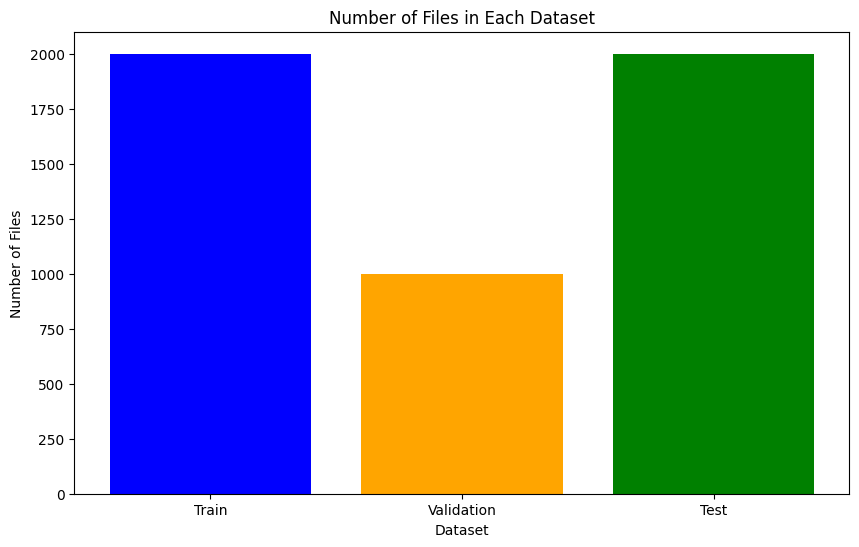

```python
import matplotlib.pyplot as plt
# Function to count the number of files in a dataset
def count_files(dataset):
    count = 0
    for _ in dataset.unbatch():
        count += 1
    return count

# Get the number of files in each dataset
train_files = count_files(train_dataset)
validation_files = count_files(validation_dataset)
test_files = count_files(test_dataset)

# Plot the number of files using a bar chart
datasets = ['Train', 'Validation', 'Test']
file_counts = [train_files, validation_files, test_files]

plt.figure(figsize=(10, 6))
plt.bar(datasets, file_counts, color=['blue', 'orange', 'green'])
plt.title('Number of Files in Each Dataset')
plt.xlabel('Dataset')
plt.ylabel('Number of Files')
plt.show()
```

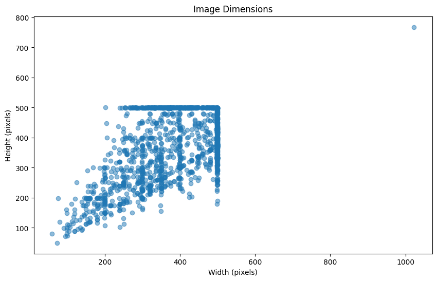

```python
import os
from PIL import Image

# Assuming the dataset is organized in directories for each class
data_dir = "data/kaggle_dogs_vs_cats_small/train"
classes = ["cat", "dog"]

# Function to get image dimensions
def get_image_dimensions(directory, classes):
    widths = []
    heights = []
    for cls in classes:
        class_dir = os.path.join(directory, cls)
        for filename in os.listdir(class_dir):
            if filename.endswith(".jpg"):
                with Image.open(os.path.join(class_dir, filename)) as img:
                    widths.append(img.width)
                    heights.append(img.height)
    return widths, heights

# Get image dimensions
widths, heights = get_image_dimensions(data_dir, classes)

# Plot the image dimensions
plt.figure(figsize=(10, 6))
plt.scatter(widths, heights, alpha=0.5)
plt.title('Image Dimensions')
plt.xlabel('Width (pixels)')
plt.ylabel('Height (pixels)')
plt.show()
```

### **Modeling**

```python
import tensorflow as tf
from tensorflow.keras import layers, models
from tensorflow.keras.callbacks import ModelCheckpoint

# Define the neural network
def create_neural_network_model():
    inputs = keras.Input(shape=(180, 180, 3))
    x = data_augmentation(inputs)
    x = layers.Rescaling(1./255)(x)
    x = layers.Conv2D(filters=32, kernel_size=3, activation="relu")(x)
    x = layers.MaxPooling2D(pool_size=2)(x)
    x = layers.Conv2D(filters=64, kernel_size=3, activation="relu")(x)
    x = layers.MaxPooling2D(pool_size=2)(x)
    x = layers.Conv2D(filters=128, kernel_size=3, activation="relu")(x)
    x = layers.MaxPooling2D(pool_size=2)(x)
    x = layers.Conv2D(filters=256, kernel_size=3, activation="relu")(x)
    x = layers.MaxPooling2D(pool_size=2)(x)
    x = layers.Conv2D(filters=256, kernel_size=3, activation="relu")(x)
    x = layers.Flatten()(x)
    x = layers.Dropout(0.5)(x)
    outputs = layers.Dense(1, activation="sigmoid")(x)
    model = keras.Model(inputs=inputs, outputs=outputs)
    return model

data_augmentation = keras.Sequential(
    [
        layers.RandomFlip("horizontal"),
        layers.RandomRotation(0.1),
        layers.RandomZoom(0.2),
    ]
)

model = create_neural_network_model()
model.compile(loss="binary_crossentropy",
              optimizer="rmsprop",
              metrics=["accuracy"])

callbacks = [
    keras.callbacks.ModelCheckpoint(
        filepath="./models/convnet_from_scratch.keras",
        save_best_only=True,
        monitor="val_loss")
]
history = model.fit(
    train_dataset,
    epochs=30,
    validation_data=validation_dataset,
    callbacks=callbacks)
```

```
63/63 ━━━━━━━━━━━━━━━━━━━━ 16s 236ms/step - accuracy: 0.5209 - loss: 0.7038 - val_accuracy: 0.5000 - val_loss: 0.6927
63/63 ━━━━━━━━━━━━━━━━━━━━ 16s 250ms/step - accuracy: 0.4960 - loss: 0.6936 - val_accuracy: 0.5000 - val_loss: 0.6921
63/63 ━━━━━━━━━━━━━━━━━━━━ 19s 295ms/step - accuracy: 0.5005 - loss: 0.7000 - val_accuracy: 0.5640 - val_loss: 0.6906
63/63 ━━━━━━━━━━━━━━━━━━━━ 19s 300ms/step - accuracy: 0.5646 - loss: 0.6889 - val_accuracy: 0.5620 - val_loss: 0.6762
63/63 ━━━━━━━━━━━━━━━━━━━━ 17s 274ms/step - accuracy: 0.5857 - loss: 0.6735 - val_accuracy: 0.6480 - val_loss: 0.6558
63/63 ━━━━━━━━━━━━━━━━━━━━ 17s 269ms/step - accuracy: 0.6169 - loss: 0.6606 - val_accuracy: 0.6370 - val_loss: 0.6345
63/63 ━━━━━━━━━━━━━━━━━━━━ 17s 273ms/step - accuracy: 0.6372 - loss: 0.6456 - val_accuracy: 0.5440 - val_loss: 0.7041
63/63 ━━━━━━━━━━━━━━━━━━━━ 18s 286ms/step - accuracy: 0.6115 - loss: 0.6546 - val_accuracy: 0.6550 - val_loss: 0.6181
63/63 ━━━━━━━━━━━━━━━━━━━━ 17s 277ms/step - accuracy: 0.6444 - loss: 0.6337 - val_accuracy: 0.6680 - val_loss: 0.5973
63/63 ━━━━━━━━━━━━━━━━━━━━ 17s 277ms/step - accuracy: 0.6738 - loss: 0.6225 - val_accuracy: 0.6850 - val_loss: 0.5879
63/63 ━━━━━━━━━━━━━━━━━━━━ 18s 280ms/step - accuracy: 0.6611 - loss: 0.5941 - val_accuracy: 0.6830 - val_loss: 0.5912
63/63 ━━━━━━━━━━━━━━━━━━━━ 18s 291ms/step - accuracy: 0.7049 - loss: 0.5816 - val_accuracy: 0.6620 - val_loss: 0.6352
63/63 ━━━━━━━━━━━━━━━━━━━━ 18s 287ms/step - accuracy: 0.7116 - loss: 0.5716 - val_accuracy: 0.6930 - val_loss: 0.6014
63/63 ━━━━━━━━━━━━━━━━━━━━ 18s 288ms/step - accuracy: 0.7209 - loss: 0.5615 - val_accuracy: 0.6800 - val_loss: 0.6053
63/63 ━━━━━━━━━━━━━━━━━━━━ 18s 291ms/step - accuracy: 0.7161 - loss: 0.5674 - val_accuracy: 0.7370 - val_loss: 0.5231
63/63 ━━━━━━━━━━━━━━━━━━━━ 20s 320ms/step - accuracy: 0.7231 - loss: 0.5594 - val_accuracy: 0.7210 - val_loss: 0.5819
63/63 ━━━━━━━━━━━━━━━━━━━━ 19s 309ms/step - accuracy: 0.7404 - loss: 0.5292 - val_accuracy: 0.7440 - val_loss: 0.5267
63/63 ━━━━━━━━━━━━━━━━━━━━ 19s 294ms/step - accuracy: 0.7437 - loss: 0.5224 - val_accuracy: 0.7570 - val_loss: 0.5125
63/63 ━━━━━━━━━━━━━━━━━━━━ 19s 299ms/step - accuracy: 0.7432 - loss: 0.5177 - val_accuracy: 0.7430 - val_loss: 0.5378
63/63 ━━━━━━━━━━━━━━━━━━━━ 21s 326ms/step - accuracy: 0.7598 - loss: 0.5124 - val_accuracy: 0.7730 - val_loss: 0.4750
63/63 ━━━━━━━━━━━━━━━━━━━━ 22s 349ms/step - accuracy: 0.7784 - loss: 0.4717 - val_accuracy: 0.7460 - val_loss: 0.5141
63/63 ━━━━━━━━━━━━━━━━━━━━ 22s 356ms/step - accuracy: 0.7568 - loss: 0.4856 - val_accuracy: 0.7720 - val_loss: 0.5635
63/63 ━━━━━━━━━━━━━━━━━━━━ 22s 342ms/step - accuracy: 0.7655 - loss: 0.4808 - val_accuracy: 0.7230 - val_loss: 0.6436
63/63 ━━━━━━━━━━━━━━━━━━━━ 20s 312ms/step - accuracy: 0.7823 - loss: 0.4881 - val_accuracy: 0.7570 - val_loss: 0.4980
63/63 ━━━━━━━━━━━━━━━━━━━━ 21s 339ms/step - accuracy: 0.7879 - loss: 0.4376 - val_accuracy: 0.7910 - val_loss: 0.4397
63/63 ━━━━━━━━━━━━━━━━━━━━ 20s 314ms/step - accuracy: 0.7703 - loss: 0.4601 - val_accuracy: 0.7410 - val_loss: 0.5441
63/63 ━━━━━━━━━━━━━━━━━━━━ 19s 308ms/step - accuracy: 0.8098 - loss: 0.4242 - val_accuracy: 0.7240 - val_loss: 0.6830
63/63 ━━━━━━━━━━━━━━━━━━━━ 25s 393ms/step - accuracy: 0.7875 - loss: 0.4414 - val_accuracy: 0.8010 - val_loss: 0.4390
63/63 ━━━━━━━━━━━━━━━━━━━━ 23s 358ms/step - accuracy: 0.8004 - loss: 0.4229 - val_accuracy: 0.7640 - val_loss: 0.5437
63/63 ━━━━━━━━━━━━━━━━━━━━ 20s 318ms/step - accuracy: 0.8129 - loss: 0.4199 - val_accuracy: 0.7900 - val_loss: 0.4713
```

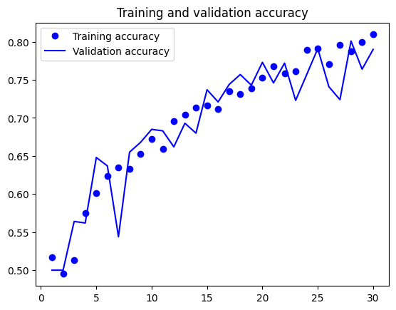

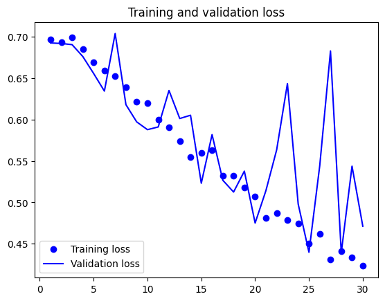

```python
import matplotlib.pyplot as plt
acc = history.history["accuracy"]
val_acc = history.history["val_accuracy"]
loss = history.history["loss"]
val_loss = history.history["val_loss"]
epochs = range(1, len(acc) + 1)
plt.plot(epochs, acc, "bo", label="Training accuracy")
plt.plot(epochs, val_acc, "b", label="Validation accuracy")
plt.title("Training and validation accuracy")
plt.legend()
plt.figure()
plt.plot(epochs, loss, "bo", label="Training loss")
plt.plot(epochs, val_loss, "b", label="Validation loss")
plt.title("Training and validation loss")
plt.legend()
plt.show()
```

Overfitting can be spoted around epoch 23, where the validation loss starts starts losing consistancy, showing the model could potentially preform poorly on some data despite improving on the training set.

```python
conv_base = keras.applications.vgg16.VGG16(
    weights="imagenet",
    include_top=False,
    input_shape=(180, 180, 3))

def get_features_and_labels(dataset):
    all_features = []
    all_labels = []
    for images, labels in dataset:
        preprocessed_images = keras.applications.vgg16.preprocess_input(images)
        features = conv_base.predict(preprocessed_images)
        all_features.append(features)
        all_labels.append(labels)
    return np.concatenate(all_features), np.concatenate(all_labels)

train_features, train_labels =  get_features_and_labels(train_dataset)
val_features, val_labels =  get_features_and_labels(validation_dataset)
test_features, test_labels =  get_features_and_labels(test_dataset)
```

[output not shown]

[output cut: 103 more lines]

[output not shown]

```python
inputs = keras.Input(shape=(5, 5, 512))
x = layers.Flatten()(inputs)
x = layers.Dense(256)(x)
x = layers.Dropout(0.5)(x)
outputs = layers.Dense(1, activation="sigmoid")(x)
VGG16_model = keras.Model(inputs, outputs)

VGG16_model.compile(loss="binary_crossentropy",
              optimizer="rmsprop",
              metrics=["accuracy"])

VGG16_callbacks = [
    keras.callbacks.ModelCheckpoint(
      filepath="./models/feature_extraction.keras",
      save_best_only=True,
      monitor="val_loss")
]
VGG16_history = VGG16_model.fit(
    train_features, train_labels,
    epochs=20,
    validation_data=(val_features, val_labels),
    callbacks=callbacks)
```

```
63/63 ━━━━━━━━━━━━━━━━━━━━ 2s 17ms/step - accuracy: 0.8656 - loss: 64.8184 - val_accuracy: 0.9020 - val_loss: 16.5514
63/63 ━━━━━━━━━━━━━━━━━━━━ 1s 13ms/step - accuracy: 0.9794 - loss: 3.2293 - val_accuracy: 0.9540 - val_loss: 8.8309
63/63 ━━━━━━━━━━━━━━━━━━━━ 1s 13ms/step - accuracy: 0.9807 - loss: 2.1057 - val_accuracy: 0.9810 - val_loss: 3.2843
63/63 ━━━━━━━━━━━━━━━━━━━━ 1s 14ms/step - accuracy: 0.9871 - loss: 1.4412 - val_accuracy: 0.9780 - val_loss: 2.9987
63/63 ━━━━━━━━━━━━━━━━━━━━ 1s 14ms/step - accuracy: 0.9944 - loss: 0.5143 - val_accuracy: 0.9700 - val_loss: 4.9523
63/63 ━━━━━━━━━━━━━━━━━━━━ 1s 14ms/step - accuracy: 0.9988 - loss: 0.0521 - val_accuracy: 0.9660 - val_loss: 7.1039
63/63 ━━━━━━━━━━━━━━━━━━━━ 1s 14ms/step - accuracy: 0.9974 - loss: 0.0849 - val_accuracy: 0.9690 - val_loss: 5.5857
63/63 ━━━━━━━━━━━━━━━━━━━━ 1s 14ms/step - accuracy: 0.9982 - loss: 0.1229 - val_accuracy: 0.9750 - val_loss: 4.2660
63/63 ━━━━━━━━━━━━━━━━━━━━ 1s 14ms/step - accuracy: 0.9972 - loss: 0.1461 - val_accuracy: 0.9710 - val_loss: 5.6910
63/63 ━━━━━━━━━━━━━━━━━━━━ 1s 14ms/step - accuracy: 0.9985 - loss: 0.1061 - val_accuracy: 0.9730 - val_loss: 4.0631
63/63 ━━━━━━━━━━━━━━━━━━━━ 1s 14ms/step - accuracy: 0.9971 - loss: 0.3858 - val_accuracy: 0.9690 - val_loss: 5.2657
63/63 ━━━━━━━━━━━━━━━━━━━━ 1s 14ms/step - accuracy: 0.9970 - loss: 0.2531 - val_accuracy: 0.9660 - val_loss: 7.5067
63/63 ━━━━━━━━━━━━━━━━━━━━ 1s 15ms/step - accuracy: 0.9962 - loss: 0.0884 - val_accuracy: 0.9730 - val_loss: 4.1631
63/63 ━━━━━━━━━━━━━━━━━━━━ 1s 14ms/step - accuracy: 0.9984 - loss: 0.0650 - val_accuracy: 0.9740 - val_loss: 4.3261
63/63 ━━━━━━━━━━━━━━━━━━━━ 1s 15ms/step - accuracy: 0.9971 - loss: 0.3038 - val_accuracy: 0.9750 - val_loss: 4.8066
63/63 ━━━━━━━━━━━━━━━━━━━━ 1s 15ms/step - accuracy: 0.9986 - loss: 0.2555 - val_accuracy: 0.9800 - val_loss: 3.7847
63/63 ━━━━━━━━━━━━━━━━━━━━ 1s 15ms/step - accuracy: 0.9969 - loss: 0.2445 - val_accuracy: 0.9750 - val_loss: 6.1489
63/63 ━━━━━━━━━━━━━━━━━━━━ 1s 14ms/step - accuracy: 0.9977 - loss: 0.1767 - val_accuracy: 0.9770 - val_loss: 4.6173
63/63 ━━━━━━━━━━━━━━━━━━━━ 1s 14ms/step - accuracy: 1.0000 - loss: 0.0000e+00 - val_accuracy: 0.9770 - val_loss: 4.6173
63/63 ━━━━━━━━━━━━━━━━━━━━ 1s 14ms/step - accuracy: 0.9987 - loss: 0.1436 - val_accuracy: 0.9820 - val_loss: 3.7877
```

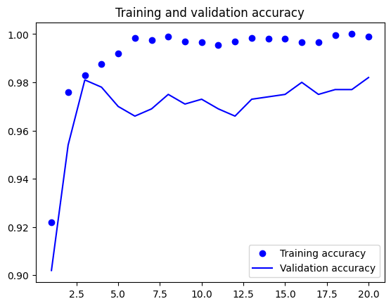

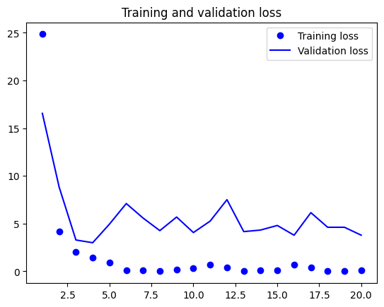

```python
import matplotlib.pyplot as plt

acc = VGG16_history.history["accuracy"]
val_acc = VGG16_history.history["val_accuracy"]
loss = VGG16_history.history["loss"]
val_loss = VGG16_history.history["val_loss"]
epochs = range(1, len(acc) + 1)
plt.plot(epochs, acc, "bo", label="Training accuracy")
plt.plot(epochs, val_acc, "b", label="Validation accuracy")
plt.title("Training and validation accuracy")
plt.legend()
plt.figure()
plt.plot(epochs, loss, "bo", label="Training loss")
plt.plot(epochs, val_loss, "b", label="Validation loss")
plt.title("Training and validation loss")
plt.legend()
plt.show()
```

## **Evaluation**

Neural Network Evaluation:

```python
from tensorflow.keras.models import load_model
import tensorflow as tf
from tensorflow.keras import layers, models
from tensorflow.keras.callbacks import ModelCheckpoint

# Load the best saved model
best_model = load_model("./models/convnet_from_scratch.keras")
```

```python
# Evaluate the model on the validation dataset
test_loss, test_accuracy = best_model.evaluate(test_dataset)
print(f"Test Accuracy: {test_accuracy:.4f}")
```

```
63/63 ━━━━━━━━━━━━━━━━━━━━ 4s 67ms/step - accuracy: 0.7750 - loss: 0.5174
Test Accuracy: 0.7865
```

```python
import numpy as np
from sklearn.metrics import confusion_matrix, classification_report, precision_recall_curve, auc

# Generate predictions
y_true = np.concatenate([y for x, y in test_dataset], axis=0)
y_pred = best_model.predict(test_dataset)
y_pred_classes = np.where(y_pred > 0.5, 1, 0)
```

```
63/63 ━━━━━━━━━━━━━━━━━━━━ 5s 76ms/step
```

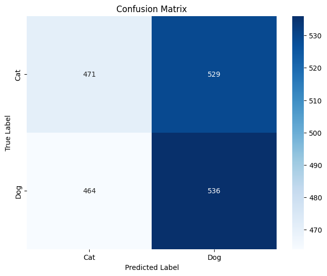

```python
import seaborn as sns
# Calculate confusion matrix
conf_matrix = confusion_matrix(test_labels, y_pred_classes)

# Plot confusion matrix
plt.figure(figsize=(8, 6))
sns.heatmap(conf_matrix, annot=True, fmt='d', cmap='Blues', xticklabels=['Cat', 'Dog'], yticklabels=['Cat', 'Dog'])
plt.xlabel('Predicted Label')
plt.ylabel('True Label')
plt.title('Confusion Matrix')
plt.show()
```

```python
# Classification Report
report = classification_report(y_true, y_pred_classes, target_names=["Cat", "Dog"])
print("Classification Report:")
print(report)
```

```
Classification Report:
              precision    recall  f1-score   support

         Cat       0.48      0.45      0.47      1000
         Dog       0.48      0.52      0.50      1000

    accuracy                           0.48      2000
   macro avg       0.48      0.48      0.48      2000
weighted avg       0.48      0.48      0.48      2000
```

```
Precision-Recall AUC: 0.4859
```

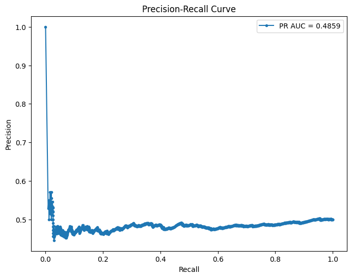

```python
# Precision-Recall Curve
precision, recall, _ = precision_recall_curve(y_true, y_pred)
pr_auc = auc(recall, precision)
print(f"Precision-Recall AUC: {pr_auc:.4f}")

# Plot Precision-Recall Curve
plt.figure(figsize=(8, 6))
plt.plot(recall, precision, marker='.', label=f'PR AUC = {pr_auc:.4f}')
plt.xlabel('Recall')
plt.ylabel('Precision')
plt.title('Precision-Recall Curve')
plt.legend()
plt.show()
```

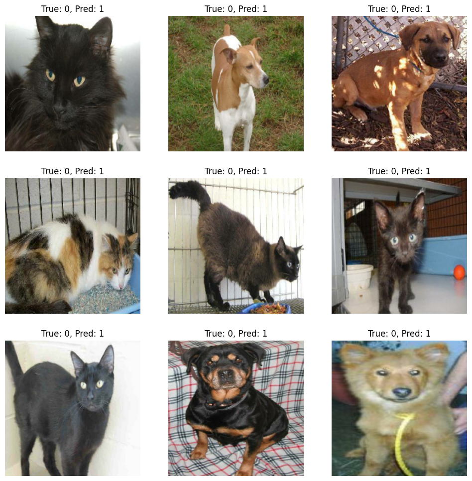

```python
# Identify misclassified examples
misclassified_indices = np.where(y_true != y_pred_classes)[0]

def plot_misclassified_examples(dataset, misclassified_indices, y_true, y_pred_classes):
    plt.figure(figsize=(12, 12))
    for i, idx in enumerate(misclassified_indices[:9]):  # Plot up to 9 misclassified examples
        plt.subplot(3, 3, i + 1)
        img = dataset.unbatch().skip(idx).take(1)
        for image, label in img:
            plt.imshow(image.numpy().astype("uint8"))
            plt.title(f"True: {int(y_true[idx])}, Pred: {int(y_pred_classes[idx])}")
            plt.axis("off")
    plt.show()

# Plot misclassified examples
plot_misclassified_examples(test_dataset, misclassified_indices, y_true, y_pred_classes)
```

VGG16 Network Evaluation:

```python
# Load the best saved model
best_VGG16_model = load_model("./models/feature_extraction.keras")
```

```python
test_loss, test_acc = best_VGG16_model.evaluate(x=test_features, y=test_labels)
print(f"Test accuracy: {test_acc:.3f}")
```

```
63/63 ━━━━━━━━━━━━━━━━━━━━ 0s 1ms/step - accuracy: 0.9809 - loss: 3.6928
Test accuracy: 0.973
```

```python
from sklearn.metrics import accuracy_score, confusion_matrix, precision_recall_fscore_support, precision_recall_curve
# Generate predictions on the validation dataset
test_predictions = best_VGG16_model.predict(test_features)
test_predictions_classes = np.where(test_predictions > 0.5, 1, 0)

# Calculate accuracy
accuracy = accuracy_score(test_labels, test_predictions_classes)
print(f"Test Accuracy: {accuracy:.4f}")
```

```
63/63 ━━━━━━━━━━━━━━━━━━━━ 0s 2ms/step
Test Accuracy: 0.9725
```

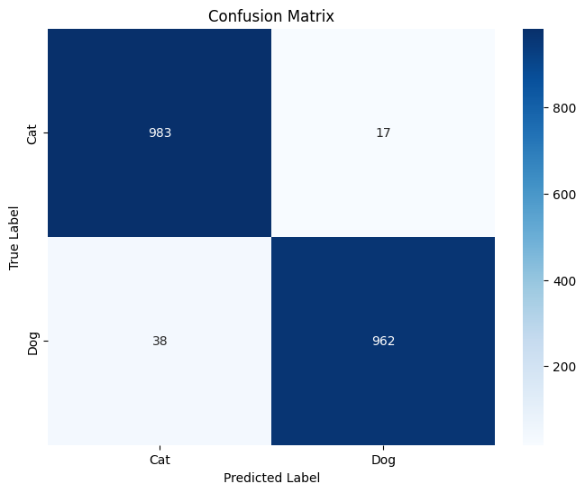

```python
import seaborn as sns

conf_matrix = confusion_matrix(test_labels, test_predictions_classes)

# Plot confusion matrix
plt.figure(figsize=(8, 6))
sns.heatmap(conf_matrix, annot=True, fmt='d', cmap='Blues', xticklabels=['Cat', 'Dog'], yticklabels=['Cat', 'Dog'])
plt.xlabel('Predicted Label')
plt.ylabel('True Label')
plt.title('Confusion Matrix')
plt.show()
```

```python
# Calculate precision, recall, and F1-score
precision, recall, f1_score, _ = precision_recall_fscore_support(test_labels, test_predictions_classes, average='binary')
print(f"Precision: {precision:.4f}")
print(f"Recall: {recall:.4f}")
print(f"F1-Score: {f1_score:.4f}")
```

```
Precision: 0.9826
Recall: 0.9620
F1-Score: 0.9722
```

```
63/63 ━━━━━━━━━━━━━━━━━━━━ 0s 1ms/step
Precision-Recall AUC: 0.9863
```

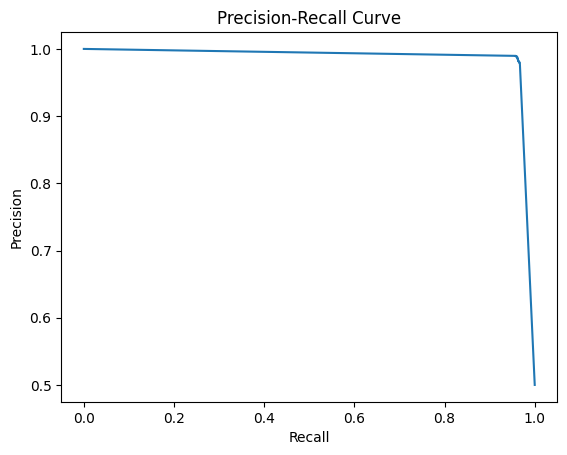

```python
# Plot precision-recall curve
from sklearn.metrics import precision_recall_curve

precision, recall, thresholds = precision_recall_curve(test_labels, VGG16_model.predict(test_features))
pr_auc = auc(recall, precision)
print(f"Precision-Recall AUC: {pr_auc:.4f}")
plt.plot(recall, precision)
plt.xlabel("Recall")
plt.ylabel("Precision")
plt.title("Precision-Recall Curve")
plt.show()
```

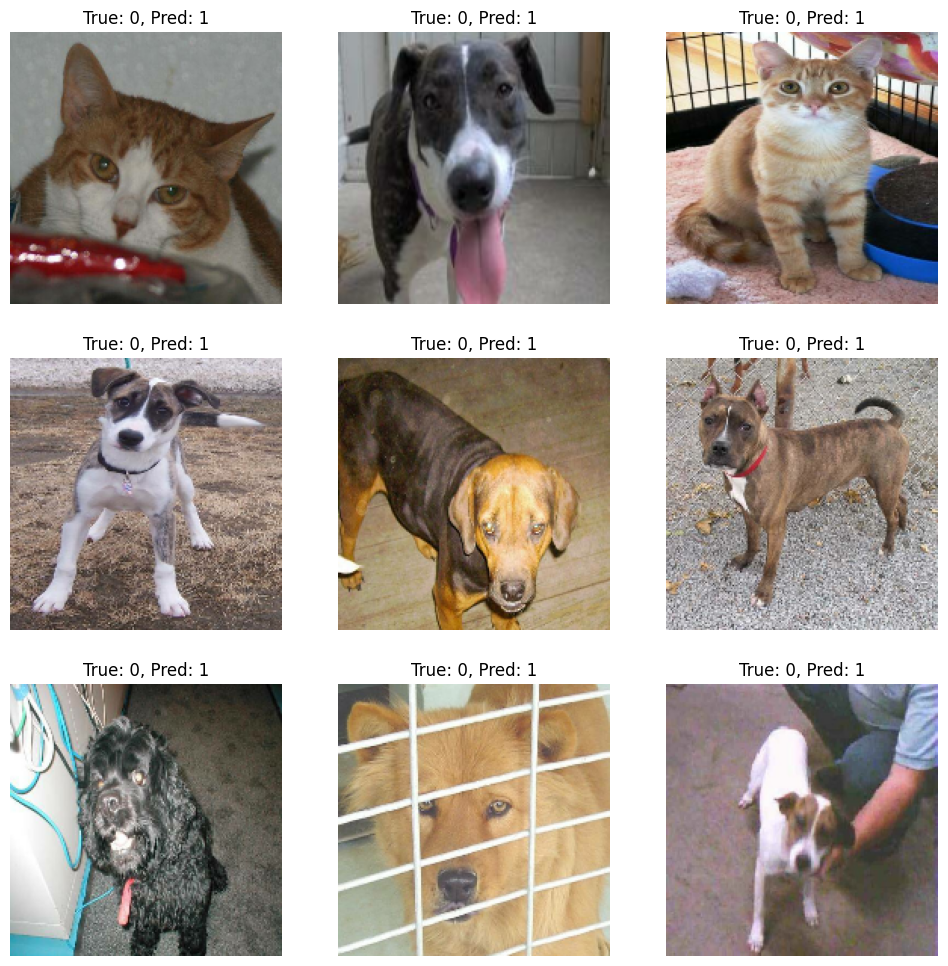

```python
misclassified_indices = np.where(y_pred_classes != test_labels)[0]

plt.figure(figsize=(12, 12))
for i, idx in enumerate(misclassified_indices[:9]):  # Plot up to 9 misclassified examples
    plt.subplot(3, 3, i + 1)
    img = validation_dataset.unbatch().skip(idx).take(1)
    for image, label in img:
        plt.imshow(image.numpy().astype("uint8"))
        plt.title(f"True: {int(y_true[idx])}, Pred: {int(y_pred_classes[idx])}")
        plt.axis("off")
plt.show()
```

## Conclusion

### **Neural Network**

Neural Network Recap:

- Test Accuracy: 0.7865
- Confusion Matrix:  
  [[471, 529],  
  [464, 536]]
- Precision: 0.48 for both the classes
- Recall: 0.45 for Cat, 0.52 for Dog
- F1-Score: 0.47 for Cat, 0.50 for Dog
- Overall Accuracy: 0.48
- PR AUC: 0.49

Neural Network Summary:

- The neural network model shows a moderate performance with accuracy of 0.7865.
- The confusion matrix indicates that the model has a balanced but relatively low precision and recall for both classes, which is verified through the classification report.
- The F1-scores suggest that the model struggles to balance the precision and recall, indicating room for improvement in distinguishing between cats and dogs.
- The PR AUC of 0.49 indicates that the model's predicitons are not much better compared to completely random guesses.

### **VGG16 Network**

VGG16 Network Recap:

- Test Accuracy: 0.973
- Confusion Matrix:  
  [[983, 17],  
  [38, 962]]
- Precision: 0.983
- Recall: 0.962
- F1-Score: 0.972
- PR AUC: 0.986

VGG16 Network Summary:

- The VGG16 model significantly outperforms the custom neural network with a much higher accuracy of 0.973.
- The confusion matrix shows that the model correctly classifies most instances, with very few misclassifications, more data to train the model could improve this.
- High precision and recall values indicate that the model is very effective at distinguishing between cats and dogs.
- The F1-score of 0.972 suggests a balance between precision and recall, making this model highly reliable.
- The PR AUC of 0.986 means that the model is very accurate in predictions, and is nearly perfect, with some minor misses.

In conclusion, the higher preforming model in this analysis is the VGG16 model, which is the more dominant model in all of the evaluation tasks.